# Condition Based Monitoring **Burning Motors**

Feature Engineering | Thresholding Setting | Condition Quantification

[figure not shown]

### Preamble

This one day project was an emergency response to the spate of motor burns on the BPLRT. The objective was to find an engineering-based scoring metric that could be used to filter out the motors that were at higher risk of burning so that they could be removed from the network and serviced. Since there was no time for validation, the model's effectiveness was based on backtest results.

Aside from the rapid identification and direct application of engineering insights based on research which correlated motor resistance, temperature and life to carbon brush-rotor interfaces (Shin, WG., Song, YS. & Seo, YK. Correlation analysis of brush temperature in brush-type DC motor for predicting motor life. J Mech Sci Technol 26, 2151–2154 (2012). https://doi.org/10.1007/s12206-012-0534-0), this project relied on direct feedback on visualizations of the data over time from the maintenance team to determine their preferred mode of quantifying a motor's risk of burning. The ideation process based on visualized data allowed for different ideas to be tested and the backtesting of the methods from the ideas eventually quantitatively determined the best idea.

# Data Processing

```python
# Combine all data into one dataframe

      import os
      import pandas as pd
      import xlrd

      pd.options.mode.chained_assignment = None  # default='warn'

      path = os.getcwd()
      df1 = pd.DataFrame()
      df2 = pd.DataFrame()

      xls = xlrd.open_workbook(path + '\\' + 'BURNS.xls')
      for sheet_name in xls.sheet_names():
          print('INCLUDED TRAIN: ' + str(sheet_name))
          df1 = df1.append(pd.read_excel(xls, sheet_name=sheet_name, skiprows=2,usecols=[i for i in range(16)]), ignore_index=True)
          df2 = df2.append(pd.read_excel(xls, sheet_name=sheet_name, skiprows=2,usecols=[i for i in range(16,32)]), ignore_index=True)

      col_name_remap = {}
      for col_1_name,col_2_name in zip(df1.columns,df2.columns):
          col_name_remap[col_2_name] = col_1_name

      df2.rename(columns=col_name_remap, inplace=True)

      df = df1.append(df2)
      df.reset_index(inplace=True)
      df.to_excel("combined_files.xlsx")      #assign name of the excel file you want to output the combined files as

      df.columns
```

```
INCLUDED TRAIN: V101
      INCLUDED TRAIN: V102
      INCLUDED TRAIN: V103
      INCLUDED TRAIN: V104
      INCLUDED TRAIN: V105
      INCLUDED TRAIN: V106
      INCLUDED TRAIN: V107
      INCLUDED TRAIN: V108
      INCLUDED TRAIN: V109
      INCLUDED TRAIN: V110
      INCLUDED TRAIN: V111
      INCLUDED TRAIN: V112
      INCLUDED TRAIN: V113
      INCLUDED TRAIN: V114
      INCLUDED TRAIN: V115
      INCLUDED TRAIN: V116
      INCLUDED TRAIN: V117
      INCLUDED TRAIN: V118
      INCLUDED TRAIN: V119
      INCLUDED TRAIN: V120
      INCLUDED TRAIN: V121
      INCLUDED TRAIN: V122
      INCLUDED TRAIN: V123
      INCLUDED TRAIN: V124
      INCLUDED TRAIN: V125
      INCLUDED TRAIN: V126
      INCLUDED TRAIN: V127
      INCLUDED TRAIN: V128
      INCLUDED TRAIN: V129
      INCLUDED TRAIN: V130
      INCLUDED TRAIN: V131
      INCLUDED TRAIN: V132
```

```
Index(['index', 'Team', 'Date', 'Odometer', 'Motor\nS/N',
             'Spring\ntab\ncolour\n(Y/R)', 'Track\n(A/B)',
             'Carbon Brush Length (mm)', 'Unnamed: 7', 'Unnamed: 8', 'Unnamed: 9',
             'Undercut\n> 0.5 mm', 'Wear rate per 10,000 km', 'Unnamed: 12',
             'Unnamed: 13', 'Unnamed: 14', 'Motor\nwear\nrate'],
            dtype='object')
```

```python
df
```

|  | index | Team | Date | Odometer | Motor\nS/N | Spring\ntab\ncolour\n(Y/R) | Track\n(A/B) | Carbon Brush Length (mm) | Unnamed: 7 | Unnamed: 8 | Unnamed: 9 | Undercut\n> 0.5 mm | Wear rate per 10,000 km | Unnamed: 12 | Unnamed: 13 | Unnamed: 14 | Motor\nwear\nrate |
| --- | --- | --- | --- | --- | --- | --- | --- | --- | --- | --- | --- | --- | --- | --- | --- | --- | --- |
| 0 | 0 | NaN | NaT | NaN | NaN | NaN | NaN | Position 1 | Position 2 | Position 3 | Position 4 | NaN | Position 1 | Position 2 | Position 3 | Position 4 | NaN |
| 1 | 1 | NaN | NaT | NaN | NaN | NaN | NaN | NaN | Track A | Track A | Track A | NaN | NaN | Track A | Track A | Track A | NaN |
| 2 | 2 | D | 2019-11-05 00:00:00 | 180637.0 | SLMA 006 | Y | A | 36.55 | 41.48 | 40.16 | 39.03 | NaN | N.A. | N.A. | N.A. | N.A. | NaN |
| 3 | 3 | NaN | 2019-11-13 00:00:00 | 182700.0 | NaN | Y | A | 38.8 | 41 | 39 | 37.06 | NaN | -10.906447 | 2.326709 | 5.622879 | 9.5492 | 5.832929 |
| 4 | 4 | C | 2019-11-21 00:00:00 | 185853.0 | NaN | Y | A | 36.59 | 38.44 | 36.43 | 35.14 | NaN | -0.076687 | 5.828221 | 7.151074 | 7.457822 | 6.812372 |
| ... | ... | ... | ... | ... | ... | ... | ... | ... | ... | ... | ... | ... | ... | ... | ... | ... | ... |
| 28637 | 14316 | NaN | NaN | NaN | NaN | NaN | NaN | NaN | NaN | NaN | NaN | NaN | NaN | NaN | NaN | NaN | 0.000000 |
| 28638 | 14317 | NaN | NaN | NaN | NaN | NaN | NaN | NaN | NaN | NaN | NaN | NaN | NaN | NaN | NaN | NaN | 0.000000 |
| 28639 | 14318 | NaN | NaN | NaN | NaN | NaN | NaN | NaN | NaN | NaN | NaN | NaN | NaN | NaN | NaN | NaN | 0.000000 |
| 28640 | 14319 | NaN | NaN | NaN | NaN | NaN | NaN | NaN | NaN | NaN | NaN | NaN | NaN | NaN | NaN | NaN | 0.000000 |
| 28641 | 14320 | NaN | NaN | NaN | NaN | NaN | NaN | NaN | NaN | NaN | NaN | NaN | NaN | NaN | NaN | NaN | 0.000000 |

28642 rows × 17 columns

```python
temp_df = pd.read_excel('combined_files.xlsx')
      cols = ['Motor\nS/N']
      temp_df.loc[:,cols] = df.loc[:,cols].ffill()

      temp_df['Motor\nS/N'] = temp_df['Motor\nS/N'].str.replace('-',"")
      temp_df['Motor\nS/N'] = temp_df['Motor\nS/N'].str.replace(' ',"")
      #temp_df['Motor\nS/N'] = temp_df['Motor\nS/N'].str.replace('25462002',"254620020")
      temp_df['Motor\nS/N'] = temp_df['Motor\nS/N'].str.replace('AO11603',"A011603")

      motor_set = sorted([str(motor_sn) for motor_sn in set(temp_df['Motor\nS/N'])])

      motor_set
      len(motor_set)
```

```
69
```

```python
motor_set
```

```
['0AIF003',
       '254620010',
       '254620011',
       '254620012',
       '254620013',
       '254620014',
       '254620015',
       '254620017',
       '254620019',
       '25462002',
       '254620020',
       '254620021',
       '254620022',
       '254620023',
       '254620024',
       '254620025',
       '254620026',
       '25462003',
       '25462004',
       '25462006',
       '25462007',
       '25462008',
       '25462009',
       '25462025',
       '25882001',
       'A011603',
       'A021602',
       'B011604',
       'B021601',
       'HOAA002',
       'HOAA003',
       'ISCAA531001',
       'OAIF001',
       'OAIF002',
       'Othermotor',
       'ROAA002',
       'ROAA003',
       'SCAA003008',
       'SCAA903007',
       'SLCP4328001',
```

[output cut: 14 more lines]

```
       'SLMA022',
       'SLMA023',
       'SLMA024',
       'SLMA025',
       'SLMA026',
       'SLMA027',
       'SLMA028',
       'SLMA030',
       'SLMA031',
       'SLMA032',
       'SLMA033',
       'SLMA034',
       'SLMA036',
       'SLMA037',
       'nan']
```

```python
temp_df.columns
      temp_df.rename(columns={'Carbon Brush Length (mm)':'Pos1_Len',
                              'Unnamed: 7':'Pos2_Len',
                              'Unnamed: 8':'Pos3_Len',
                              'Unnamed: 9':'Pos4_Len',
                              'Wear rate per 10,000 km':'Pos1_Wear_Rate',
                              'Unnamed: 12':'Pos2_Wear_Rate',
                              'Unnamed: 13':'Pos3_Wear_Rate',
                              'Unnamed: 14':'Pos4_Wear_Rate',
                             }, inplace=True)
```

```python
temp_df=temp_df[['Date','Motor\nS/N','Pos1_Len','Pos2_Len','Pos3_Len','Pos4_Len','Pos1_Wear_Rate','Pos2_Wear_Rate','Pos3_Wear_Rate','Pos4_Wear_Rate','Motor\nwear\nrate']]
      temp_df.dropna(subset=['Motor\nwear\nrate','Date','Motor\nS/N'], inplace=True)
      temp_df.reset_index(inplace=True, drop=True)
      len(temp_df)
```

```
6091
```

```python
# Clean Data

      import time
      from datetime import datetime
      from time import mktime


      for df_entry in range(len(temp_df)-1,-1,-1):
          try:
              if type(temp_df['Date'][df_entry]) == str:
                  print(temp_df['Date'][df_entry])
                  temp_df.drop(df_entry, inplace=True)

          except:
              print(temp_df['Date'][df_entry])

      temp_df.reset_index(inplace=True, drop=True)
      len(temp_df)
```

```
02/27/21
      29/09/20q
      02/27/21
      05/04/21`
      27/04/021
      02/27/21
      29/09/20q
      02/27/21
```

```
6083
```

# EDA

```python
temp_df['Pos_Wear_Variance'] = 0
      temp_df['Pos_Len_Variance'] = 0

      for df_entry in range(len(temp_df)-1,-1,-1):
          #print(temp_df['Pos1_Wear_Rate'][df_entry], temp_df['Pos2_Wear_Rate'][df_entry], temp_df['Pos3_Wear_Rate'][df_entry], temp_df['Pos4_Wear_Rate'][df_entry])
          try:
              row_wear_mean =  (temp_df['Pos1_Wear_Rate'][df_entry] + temp_df['Pos2_Wear_Rate'][df_entry] + temp_df['Pos3_Wear_Rate'][df_entry] + temp_df['Pos4_Wear_Rate'][df_entry])/4
              temp_df['Pos_Wear_Variance'][df_entry]  = (temp_df['Pos1_Wear_Rate'][df_entry] - row_wear_mean)**2 + (temp_df['Pos2_Wear_Rate'][df_entry] - row_wear_mean)**2 + (temp_df['Pos3_Wear_Rate'][df_entry] - row_wear_mean)**2 + (temp_df['Pos4_Wear_Rate'][df_entry] - row_wear_mean)**2

              row_len_mean = (temp_df['Pos1_Len'][df_entry] + temp_df['Pos2_Len'][df_entry] + temp_df['Pos3_Len'][df_entry] + temp_df['Pos4_Len'][df_entry])/4
              temp_df['Pos_Len_Variance'][df_entry]  = (temp_df['Pos1_Len'][df_entry] - row_len_mean)**2 + (temp_df['Pos2_Len'][df_entry] - row_len_mean)**2 + (temp_df['Pos3_Len'][df_entry] - row_len_mean)**2 + (temp_df['Pos4_Len'][df_entry] - row_len_mean)**2
          except:
              pass
```

```python
temp_df['Pos_Wear_Variance'].describe()
```

```
count    6.064000e+03
      mean     3.917391e+04
      std      2.824995e+06
      min      0.000000e+00
      25%      5.724688e-01
      50%      2.997480e+00
      75%      1.491303e+01
      max      2.196675e+08
      Name: Pos_Wear_Variance, dtype: float64
```

```python
temp_df['Pos_Len_Variance'].describe()
```

```
count    6068.000000
      mean       15.575714
      std        50.673626
      min         0.000000
      25%         0.786494
      50%         3.888075
      75%        13.252250
      max      2090.210000
      Name: Pos_Len_Variance, dtype: float64
```

```python
temp_df['Pos_Wear_Variance'].quantile([0.1,0.2,0.3,0.4,0.5,0.6,0.7,0.8,0.9,0.95,0.99,0.999])
```

```
0.100         0.000000
      0.200         0.292992
      0.300         0.928441
      0.400         1.730724
      0.500         2.997480
      0.600         5.375859
      0.700        10.003303
      0.800        24.440275
      0.900        93.469240
      0.950       287.044386
      0.990      2449.510376
      0.999    250552.200000
      Name: Pos_Wear_Variance, dtype: float64
```

```python
temp_df['Pos_Len_Variance'].quantile([0.1,0.2,0.3,0.4,0.5,0.6,0.7,0.8,0.9,0.95,0.99,0.999])
```

```
0.100      0.045800
      0.200      0.499445
      0.300      1.117035
      0.400      2.143980
      0.500      3.888075
      0.600      6.388555
      0.700     10.471615
      0.800     16.760570
      0.900     30.304700
      0.950     49.685735
      0.990    257.147840
      0.999    495.562548
      Name: Pos_Len_Variance, dtype: float64
```

```python
start = datetime(2020, 1, 1)
      end = datetime(2022, 3, 30)

      filtered_df = temp_df.loc[(temp_df['Date'] >= start)
                           & (temp_df['Date'] < end)]

      filtered_df.sort_values(by=['Motor\nwear\nrate'],ascending=[False],inplace=True)

      filtered_df['Motor\nwear\nrate'].describe()
```

```
count     5718.000000
      mean        20.143974
      std        455.472261
      min          0.000000
      25%          3.351039
      50%          4.866994
      75%          8.781261
      max      25925.000000
      Name: Motor\nwear\nrate, dtype: float64
```

```python
filtered_df['Motor\nwear\nrate'].quantile([0.1,0.2,0.3,0.4,0.5,0.6,0.7,0.8,0.9,0.95,0.99,0.999])
```

```
0.100      0.000000
      0.200      3.054668
      0.300      3.626772
      0.400      4.179889
      0.500      4.866994
      0.600      5.919157
      0.700      7.647813
      0.800     10.357053
      0.900     15.322252
      0.950     24.112265
      0.990     98.585213
      0.999    990.785714
      Name: Motor\nwear\nrate, dtype: float64
```

```python
print(filtered_df.loc[filtered_df['Motor\nwear\nrate']>filtered_df['Motor\nwear\nrate'].quantile(0.5)][:50])
```

```
                     Date    Motor\nS/N Pos1_Len Pos2_Len Pos3_Len Pos4_Len  \
      2931  2020-04-03 00:00:00      25462006    49.14    49.72    49.11    50.94
      1836  2022-01-24 00:00:00       OAIF002        0        0        0        0
      4954  2022-01-24 00:00:00       SLMA023        0        0        0        0
      4167  2021-06-20 00:00:00       OAIF001      NaN      NaN      NaN      NaN
      1800  2021-04-11 00:00:00       ROAA002    51.55     51.3    51.32    51.36
      4922  2021-04-11 00:00:00       SLMA023    51.95    52.02     50.5    51.51
      1835  2022-01-08 00:00:00       OAIF002    52.16    52.91    52.06    52.19
      4953  2022-01-08 00:00:00       SLMA023     52.2    52.09    52.11     52.2
      4065  2020-05-30 00:00:00       SLMA019    51.38       52     52.3    51.27
      3588  2020-02-03 00:00:00       SLMA022    52.01    52.18    51.95     52.2
      1404  2022-01-28 00:00:00       SLMA010      NaN      NaN      NaN      NaN
      1405  2022-02-05 00:00:00       SLMA010      NaN      NaN      NaN      NaN
      5285  2020-08-06 00:00:00      25462009    51.99     52.3    52.29    51.31
      2195  2020-08-06 00:00:00      25462002     52.3    51.61    52.29     51.8
```

[output cut: 140 more lines]

```python
columns = ['Date', 'Motor\nwear\nrate']

      for motor_x_sn in motor_set:
          motor_x_data = temp_df[columns].loc[temp_df['Motor\nS/N'] == motor_x_sn].sort_values(by=['Date'],ascending=[True])
          motor_x_data.set_index('Date',inplace=True)
          motor_x_data["2018-05-20":"2022-05-21"].plot(kind='line',title=motor_x_sn, figsize=(16,12))
```

```python
columns = ['Date', 'Motor\nwear\nrate']
      burn_motor_set = ['SLMA036','SLMA022','SLMA021','SLMA032']

      for motor_x_sn in burn_motor_set:
          motor_x_data = temp_df[columns].loc[temp_df['Motor\nS/N'] == motor_x_sn].sort_values(by=['Date'],ascending=[True])
          motor_x_data.set_index('Date',inplace=True)
          motor_x_data["2018-05-20":"2022-05-21"].plot(kind='line',title=motor_x_sn, figsize=(16,12))
```

[output not shown]

# Profile Burnt Motors

```
Percentage threshold exceedance:  0.5725490196078431
      Percentage threshold exceedance:  0.42359249329758714
      Percentage threshold exceedance:  0.46
      Percentage threshold exceedance:  0.23940149625935161
```

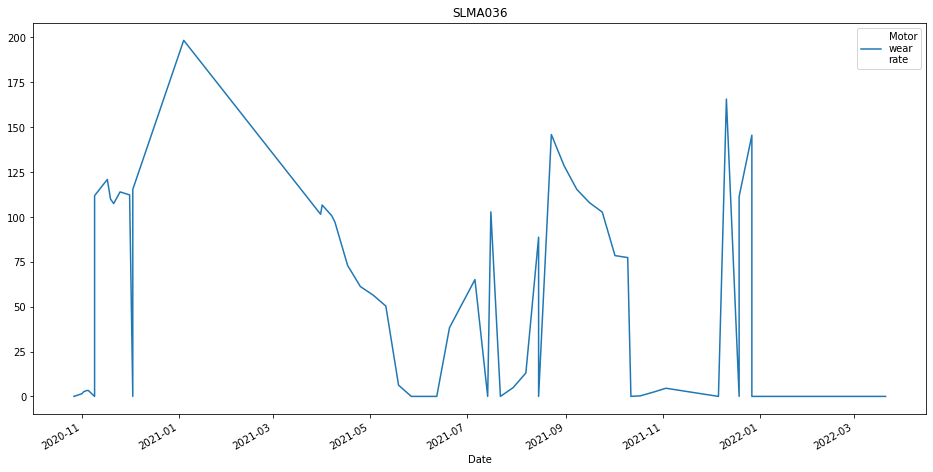

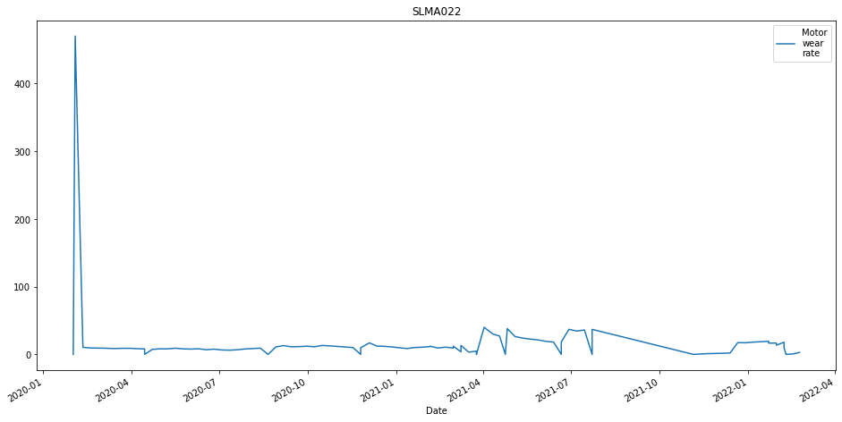

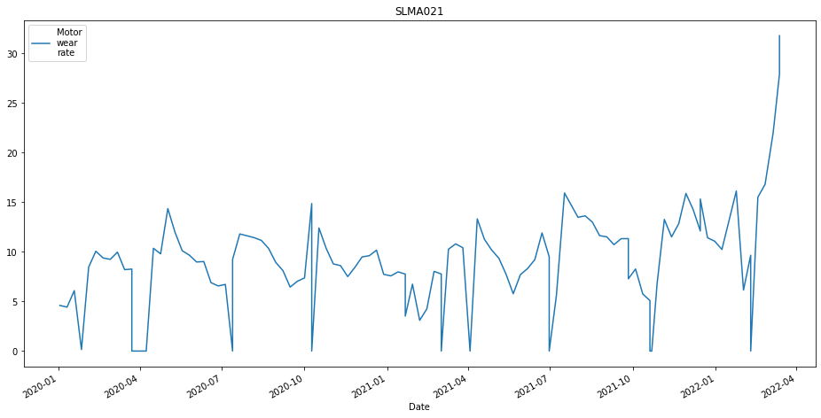

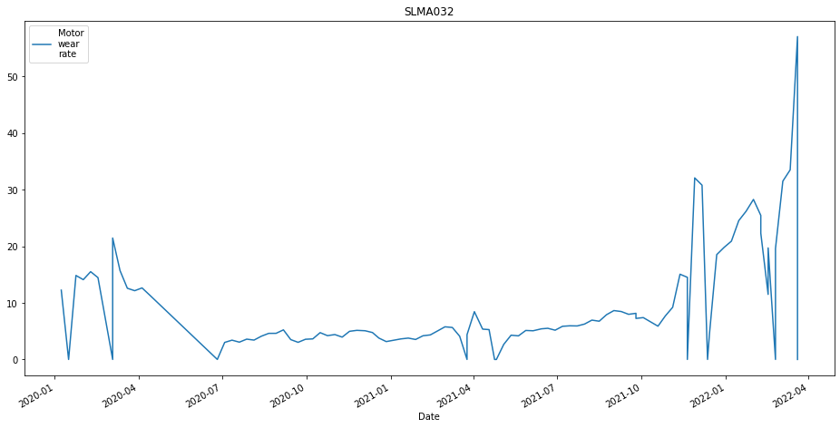

```python
columns = ['Date', 'Motor\nwear\nrate']
      burn_motor_set = ['SLMA036','SLMA022','SLMA021','SLMA032']
      start = datetime(2020, 1, 1)
      end = datetime(2022, 3, 30)

      #based on how many motors can be attended to at any point in time, derived from percentile
      threshold = 10.0

      for motor_x_sn in burn_motor_set:

          exceed_threshold = 0
          motor_x_data = temp_df[columns].loc[(temp_df['Motor\nS/N'] == motor_x_sn) & (temp_df['Date'] >= start) & (temp_df['Date'] <= end)].sort_values(by=['Date'],ascending=[True])
          motor_x_data.reset_index(inplace=True,drop=True)
          motor_x_data['Days_From_Prev_Measurement'] = 0
          for df_entry in range(1,len(motor_x_data)-1):
              motor_x_data['Days_From_Prev_Measurement'][df_entry] = motor_x_data['Date'][df_entry] - motor_x_data['Date'][df_entry-1]

          motor_x_data.set_index('Date',inplace=True, drop=True)
          motor_x_data["2018-05-20":"2022-05-21"].plot(kind='line',title=motor_x_sn, figsize=(16,8))

          motor_x_data['Days_From_Prev_Measurement'] = motor_x_data['Days_From_Prev_Measurement'].astype('timedelta64[D]')
          motor_x_data['Days_From_Prev_Measurement'] = motor_x_data['Days_From_Prev_Measurement'].dt.days

          for df_entry in range(1,len(motor_x_data)-1):
              if motor_x_data['Motor\nwear\nrate'][df_entry] > threshold:
                  exceed_threshold += motor_x_data['Days_From_Prev_Measurement'][df_entry]


          print('Percentage threshold exceedance: ', exceed_threshold/sum(motor_x_data['Days_From_Prev_Measurement']))
```

# Detect Burning Motors (Method 1)

```
Burning Motors
      OAIF001 0.3448275862068966
      SLMA025 0.3402061855670103
      ROAA002 0.3333333333333333
      25462003 0.2962962962962963
      25882001 0.2727272727272727
      254620021 0.23684210526315788
      SLMA030 0.23076923076923078
      Number of Burning Motors:  17
```

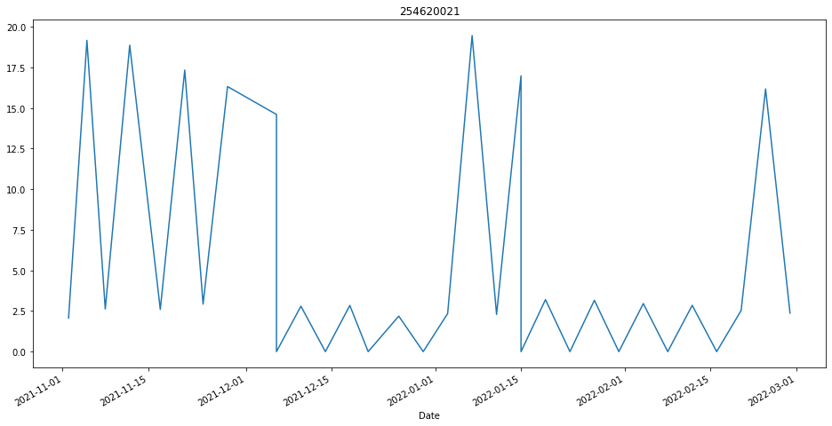

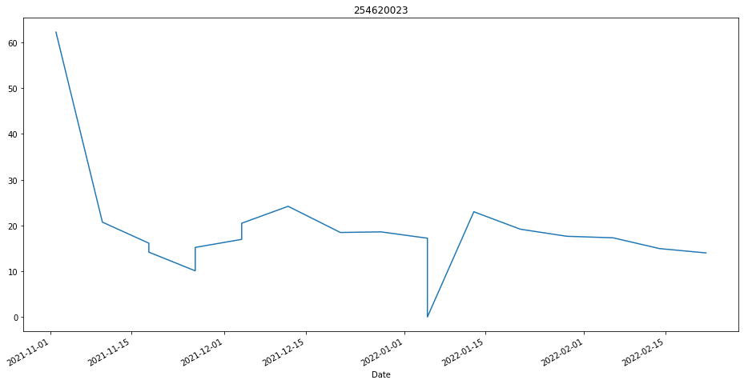

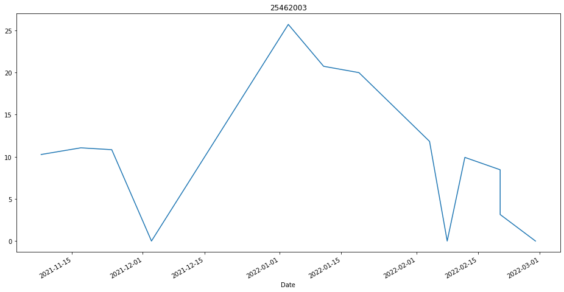

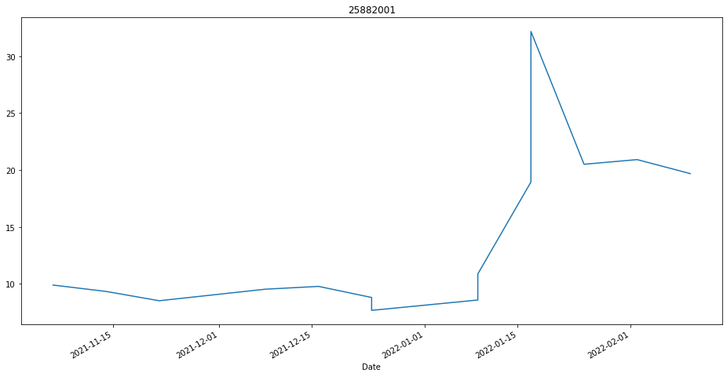

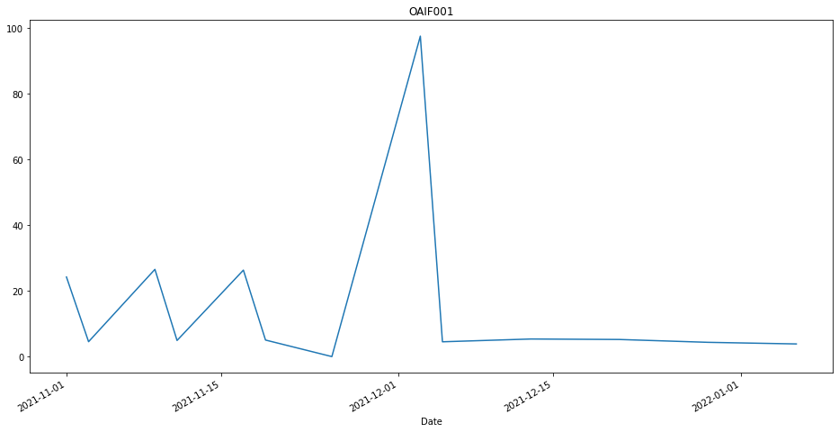

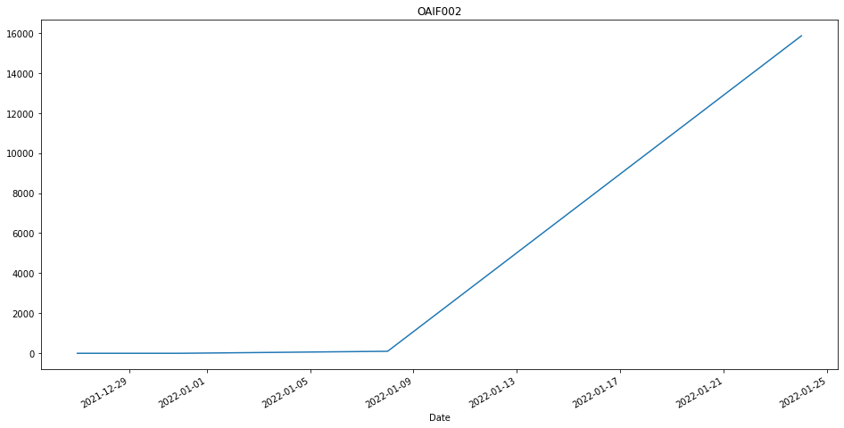

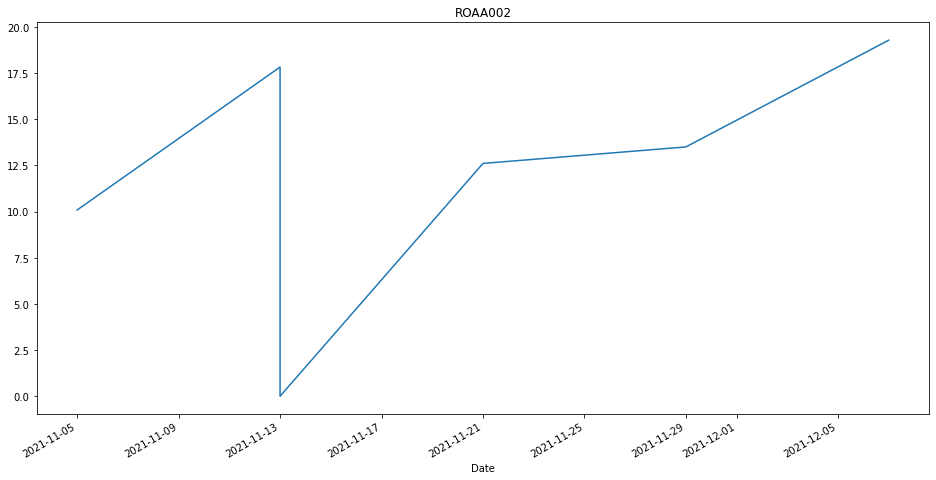

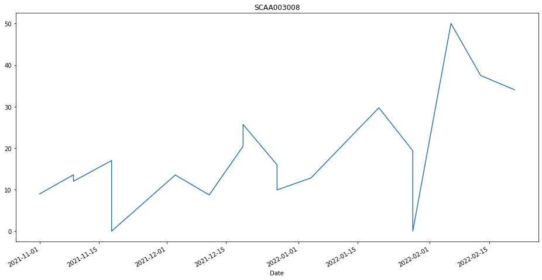

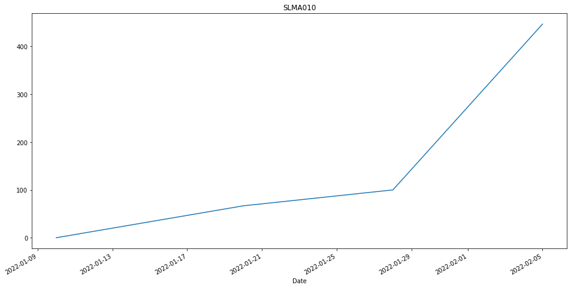

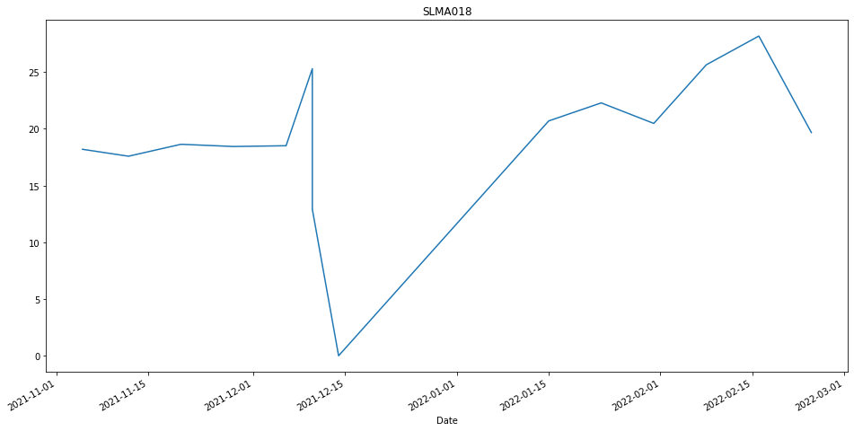

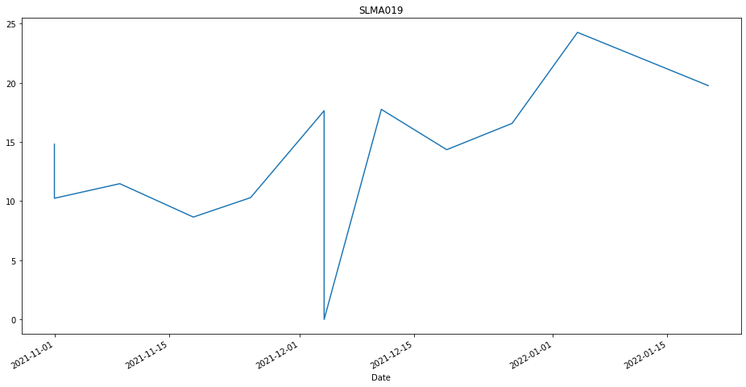

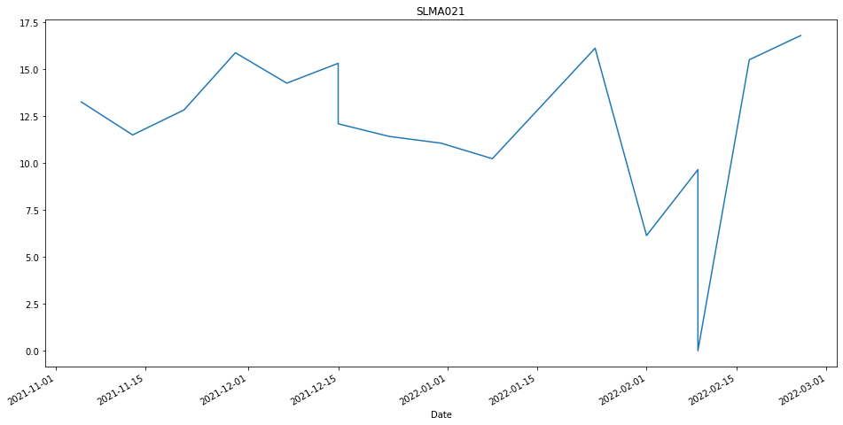

[5 more figures not shown]

```python
import matplotlib.pyplot as plt

      columns = ['Date', 'Motor\nwear\nrate']
      burning_motor_set = []
      start = datetime(2021, 11, 1)
      end = datetime(2022, 2, 28)

      #based on how many motors can be attended to at any point in time, derived from percentile
      threshold = 15.3
      exceedance_percentage_threshold = 0.20

      for motor_x_sn in motor_set:

          exceed_threshold = 0
          motor_x_data = temp_df[columns].loc[(temp_df['Motor\nS/N'] == motor_x_sn) & (temp_df['Date'] >= start) & (temp_df['Date'] <= end)].sort_values(by=['Date'],ascending=[True])
          motor_x_data.reset_index(inplace=True,drop=True)
          motor_x_data['Days_From_Prev_Measurement'] = 0
          motor_x_data['Days_From_Latest_Measurement'] = 0
          for df_entry in range(1,len(motor_x_data)-1):
              motor_x_data['Days_From_Prev_Measurement'][df_entry] = motor_x_data['Date'][df_entry] - motor_x_data['Date'][df_entry-1]
              motor_x_data['Days_From_Latest_Measurement'][df_entry] = motor_x_data['Date'][df_entry] - motor_x_data['Date'][0]

          for df_entry in range(len(motor_x_data)-1,1,-1):
              if (motor_x_data['Motor\nwear\nrate'][df_entry] == 0) and (motor_x_data['Motor\nwear\nrate'][df_entry-1] == 0):
                  motor_x_data.drop(df_entry, inplace=True)

          motor_x_data.reset_index(inplace=True,drop=True)

          motor_x_data.set_index('Date',inplace=True, drop=True)

          motor_x_data['Days_From_Prev_Measurement'] = motor_x_data['Days_From_Prev_Measurement'].astype('timedelta64[D]')
          motor_x_data['Days_From_Prev_Measurement'] = motor_x_data['Days_From_Prev_Measurement'].dt.days
          motor_x_data['Days_From_Latest_Measurement'] = motor_x_data['Days_From_Latest_Measurement'].astype('timedelta64[D]')
          motor_x_data['Days_From_Latest_Measurement'] = motor_x_data['Days_From_Latest_Measurement'].dt.days

          for df_entry in range(1,len(motor_x_data)-1):
              if motor_x_data['Motor\nwear\nrate'][df_entry] > threshold:
                  exceed_threshold += motor_x_data['Days_From_Prev_Measurement'][df_entry]
                  # set hard limit for graph visibility
                  if motor_x_data['Motor\nwear\nrate'][df_entry] > 100:
                      motor_x_data['Motor\nwear\nrate'][df_entry] = 100


          if exceed_threshold/max(1,sum(motor_x_data['Days_From_Prev_Measurement'])) > exceedance_percentage_threshold:
              burning_motor_set.append((motor_x_sn,exceed_threshold/sum(motor_x_data['Days_From_Prev_Measurement'])))
              #print(motor_x_sn, ' percentage threshold exceedance: ', exceed_threshold/sum(motor_x_data['Days_From_Prev_Measurement']))
              plt.figure(motor_x_sn)
              motor_x_data['Motor\nwear\nrate'].plot(kind='line',title=motor_x_sn, figsize=(16,8))

      print('Burning Motors')
      for motor,score in sorted(burning_motor_set, key=lambda x: x[1], reverse=True)[10:]:
          print(motor,score)


      print('Number of Burning Motors: ',len(burning_motor_set))
```

# Detect Burning Motors (Method 2)

```python
import matplotlib.pyplot as plt
      from datetime import datetime, timedelta
      import math

      columns = ['Date', 'Motor\nwear\nrate']
      burning_motor_set = []
      highscore_motor_set = []
      motor_data_set = {}
      start = datetime(2021, 12, 16)
      end = datetime(2022, 3, 16)

      date_multiplier_table = decay([30,30,30,999],[0.1,0.05,0.01,0])

      #based on how many motors can be attended to at any point in time, derived from percentile
      threshold = 15.3
      exceedance_percentage_threshold = 0.20
      min_replacements = 5

      for motor_x_sn in motor_set:

          exceed_threshold = 0
          number_replacements = 0
          motor_x_data = temp_df[columns].loc[(temp_df['Motor\nS/N'] == motor_x_sn) & (temp_df['Date'] >= start) & (temp_df['Date'] <= end)].sort_values(by=['Date'],ascending=[True])
          motor_x_data.reset_index(inplace=True,drop=True)
          motor_x_data['Days_From_Prev_Measurement'] = 0
          motor_x_data['Days_From_Latest_Measurement'] = timedelta(days=0)
          for df_entry in range(1,len(motor_x_data)-1):
              motor_x_data['Days_From_Prev_Measurement'][df_entry] = motor_x_data['Date'][df_entry] - motor_x_data['Date'][df_entry-1]
              motor_x_data['Days_From_Latest_Measurement'][df_entry] = motor_x_data['Date'][df_entry] - motor_x_data['Date'][0]

          for df_entry in range(len(motor_x_data)-1,1,-1):
              if (motor_x_data['Motor\nwear\nrate'][df_entry] == 0) and (motor_x_data['Motor\nwear\nrate'][df_entry-1] == 0):
                  motor_x_data.drop(df_entry, inplace=True)

          motor_x_data.reset_index(inplace=True,drop=True)

          #get data for only last 3 motor replacements
          for df_entry in range(len(motor_x_data)-1,1,-1):
              if (motor_x_data['Motor\nwear\nrate'][df_entry] == 0):
                  number_replacements += 1
              if number_replacements == min_replacements:
                  motor_x_data = motor_x_data[df_entry:]
                  break

          motor_x_data.reset_index(inplace=True,drop=True)

          #calculate score for wear-date measurements
          motor_x_data['Score'] = 0
          motor_x_data['Exceeded'] = 0

          for df_entry in range(len(motor_x_data)-1):
              #date score multiplier
              date_multiplier = date_multiplier_table[motor_x_data['Days_From_Latest_Measurement'][df_entry].days]
              #exceedance score
              exceedance_score = max(motor_x_data['Motor\nwear\nrate'][df_entry]-threshold,0)
              if exceedance_score:
                  motor_x_data['Exceeded'][df_entry] = 1
              #combo multiplier
              earlier_entry = df_entry-1
              combo_x = 1.1
              while earlier_entry >= 0 and motor_x_data['Exceeded'][earlier_entry]:
                  combo_x *= combo_x
                  earlier_entry -= 1

              motor_x_data['Score'][df_entry] = min(combo_x * date_multiplier * exceedance_score,9999)
      #         print(combo_x,date_multiplier,exceedance_score)
      #         print(combo_x * date_multiplier * exceedance_score)
          pass


          motor_x_data.set_index('Date',inplace=True, drop=True)


          motor_x_data['Days_From_Prev_Measurement'] = motor_x_data['Days_From_Prev_Measurement'].astype('timedelta64[D]')
          motor_x_data['Days_From_Prev_Measurement'] = motor_x_data['Days_From_Prev_Measurement'].dt.days
      #     motor_x_data['Days_From_Latest_Measurement'] = motor_x_data['Days_From_Latest_Measurement'].astype('timedelta64[D]')
      #     motor_x_data['Days_From_Latest_Measurement'] = motor_x_data['Days_From_Latest_Measurement'].dt.days

          for df_entry in range(1,len(motor_x_data)):
              if motor_x_data['Motor\nwear\nrate'][df_entry] > threshold:
                  exceed_threshold += motor_x_data['Days_From_Prev_Measurement'][df_entry]
                  # set hard limit for graph visibility
                  if motor_x_data['Motor\nwear\nrate'][df_entry] > 50:
                      motor_x_data['Motor\nwear\nrate'][df_entry] = 50

          if exceed_threshold/max(1,sum(motor_x_data['Days_From_Prev_Measurement'])) > exceedance_percentage_threshold:
              burning_motor_set.append((motor_x_sn,exceed_threshold/sum(motor_x_data['Days_From_Prev_Measurement'])))
              #print(motor_x_sn, ' percentage threshold exceedance: ', exceed_threshold/sum(motor_x_data['Days_From_Prev_Measurement']))
      #         plt.figure(motor_x_sn)
      #         motor_x_data['Motor\nwear\nrate'].plot(kind='line',title=motor_x_sn, figsize=(16,8))


          motor_data_set[motor_x_sn] = motor_x_data
          highscore_motor_set.append((motor_x_sn,sum(motor_x_data['Score'])))


      print('------------------------------------------------REPORT TIME-----------------------------------------------')
      print('**Burning Motors:**')
      sorted_burning_motors = sorted(burning_motor_set, key=lambda x: x[1], reverse=True)
      for burning_motor,score in sorted_burning_motors:
          print(burning_motor,score)

      print()

      print('**Number of Burning Motors:** ',len(burning_motor_set))

      print()

      print('**Motor Scores:**')
      sorted_motor_scores = sorted(highscore_motor_set, key=lambda x: x[1], reverse=True)
      for motor,motor_score in sorted_motor_scores:
          if motor_score > 0:
              print(motor,motor_score)
```

```
------------------------------------------------REPORT TIME-----------------------------------------------
      **Burning Motors:**
      SLMA010 1.0
      SLMA019 1.0
      SLMA032 1.0
      SLMA036 1.0
      SCAA003008 0.9
      SLMA018 0.875
      SLMA022 0.8421052631578947
      SLMA025 0.7
      OAIF002 0.6666666666666666
      SLMA021 0.6
      254620023 0.5949367088607594
      25882001 0.5
      25462003 0.375
      SLMA023 0.22727272727272727

      **Number of Burning Motors:**  14

      **Motor Scores:**
      SLMA032 29527
      SLMA023 14589
      OAIF002 4560
      SLMA018 2499
      SLMA010 2363
      SLMA036 1327
      25462008 770
      SLCP43288002 605
      SCAA003008 403
      25462007 214
      SLMA022 156
      254620023 109
      25882001 104
      SLMA025 92
      25462003 88
      SLMA019 51
      SLMA021 44
      25462006 13
      254620010 6
      254620021 3
      Othermotor 3
```

[figure not shown]

[figure not shown]

[figure not shown]

[figure not shown]

[figure not shown]

[figure not shown]

[figure not shown]

[figure not shown]

[figure not shown]

[figure not shown]

[figure not shown]

[figure not shown]

[2 more figures not shown]

```python
for motor_x_sn, exeedance_percentage in sorted_burning_motors:
          motor_x_data = motor_data_set[motor_x_sn]
          plt.figure(motor_x_sn)
          motor_x_data['Motor\nwear\nrate'].plot(kind='line',title=str(motor_x_sn) + ' | ' + str(exeedance_percentage), figsize=(16,8))
```

```python
for motor_x_sn, score in sorted(highscore_motor_set, key=lambda x: x[1], reverse=True):
          if score > 0:
              motor_x_data = motor_data_set[motor_x_sn]
              plt.figure(motor_x_sn)
              motor_x_data['Motor\nwear\nrate'].plot(kind='line',title=str(motor_x_sn) + ' | ' + str(score), figsize=(16,8))
```

# Detect Burning Motors (Method 2 + Factor Replacement Count)

```python
import matplotlib.pyplot as plt
      from datetime import datetime, timedelta
      import math

      columns = ['Date', 'Motor\nwear\nrate']
      burning_motor_set = []
      highscore_motor_set = []
      motor_data_set = {}
      start = datetime(2021, 10, 9)
      end = datetime(2022, 1, 9)

      date_multiplier_table = decay([30,30,30,999],[0.1,0.05,0.01,0])

      #based on how many motors can be attended to at any point in time, derived from percentile
      threshold = 15.3
      exceedance_percentage_threshold = 0.20
      min_replacements = 2

      for motor_x_sn in motor_set:

          exceed_threshold = 0
          number_replacements = 0
          motor_x_data = temp_df[columns].loc[(temp_df['Motor\nS/N'] == motor_x_sn) & (temp_df['Date'] >= start) & (temp_df['Date'] <= end)].sort_values(by=['Date'],ascending=[True])
          motor_x_data.reset_index(inplace=True,drop=True)
          motor_x_data['Days_From_Prev_Measurement'] = 0
          motor_x_data['Days_From_Latest_Measurement'] = timedelta(days=0)
          for df_entry in range(1,len(motor_x_data)-1):
              motor_x_data['Days_From_Prev_Measurement'][df_entry] = motor_x_data['Date'][df_entry] - motor_x_data['Date'][df_entry-1]
              motor_x_data['Days_From_Latest_Measurement'][df_entry] = motor_x_data['Date'][df_entry] - motor_x_data['Date'][0]

          for df_entry in range(len(motor_x_data)-1,1,-1):
              if (motor_x_data['Motor\nwear\nrate'][df_entry] == 0) and (motor_x_data['Motor\nwear\nrate'][df_entry-1] == 0):
                  motor_x_data.drop(df_entry, inplace=True)

          motor_x_data.reset_index(inplace=True,drop=True)

          #get data for only last 3 motor replacements
          for df_entry in range(len(motor_x_data)-1,1,-1):
              if (motor_x_data['Motor\nwear\nrate'][df_entry] == 0):
                  number_replacements += 1

          motor_x_data.reset_index(inplace=True,drop=True)

          #calculate score for wear-date measurements
          motor_x_data['Score'] = 0
          motor_x_data['Exceeded'] = 0

          for df_entry in range(len(motor_x_data)-1):
              #date score multiplier
              date_multiplier = date_multiplier_table[motor_x_data['Days_From_Latest_Measurement'][df_entry].days]
              #exceedance score
              exceedance_score = max(motor_x_data['Motor\nwear\nrate'][df_entry]-threshold,0)
              if exceedance_score:
                  motor_x_data['Exceeded'][df_entry] = 1
              #combo multiplier
              earlier_entry = df_entry-1
              combo_x = 1.1
              while earlier_entry >= 0 and motor_x_data['Exceeded'][earlier_entry]:
                  combo_x *= combo_x
                  earlier_entry -= 1

              motor_x_data['Score'][df_entry] = min(combo_x * date_multiplier * exceedance_score,9999)
      #         print(combo_x,date_multiplier,exceedance_score)
      #         print(combo_x * date_multiplier * exceedance_score)
          pass


          motor_x_data.set_index('Date',inplace=True, drop=True)


          motor_x_data['Days_From_Prev_Measurement'] = motor_x_data['Days_From_Prev_Measurement'].astype('timedelta64[D]')
          motor_x_data['Days_From_Prev_Measurement'] = motor_x_data['Days_From_Prev_Measurement'].dt.days
      #     motor_x_data['Days_From_Latest_Measurement'] = motor_x_data['Days_From_Latest_Measurement'].astype('timedelta64[D]')
      #     motor_x_data['Days_From_Latest_Measurement'] = motor_x_data['Days_From_Latest_Measurement'].dt.days

          for df_entry in range(1,len(motor_x_data)):
              if motor_x_data['Motor\nwear\nrate'][df_entry] > threshold:
                  exceed_threshold += motor_x_data['Days_From_Prev_Measurement'][df_entry]
                  # set hard limit for graph visibility
                  if motor_x_data['Motor\nwear\nrate'][df_entry] > 50:
                      motor_x_data['Motor\nwear\nrate'][df_entry] = 50

          if exceed_threshold/max(1,sum(motor_x_data['Days_From_Prev_Measurement'])) > exceedance_percentage_threshold:
              burning_motor_set.append((motor_x_sn,exceed_threshold/sum(motor_x_data['Days_From_Prev_Measurement'])))
              #print(motor_x_sn, ' percentage threshold exceedance: ', exceed_threshold/sum(motor_x_data['Days_From_Prev_Measurement']))
      #         plt.figure(motor_x_sn)
      #         motor_x_data['Motor\nwear\nrate'].plot(kind='line',title=motor_x_sn, figsize=(16,8))


          motor_data_set[motor_x_sn] = motor_x_data
          highscore_motor_set.append((motor_x_sn,sum(motor_x_data['Score']),number_replacements))


      print('------------------------------------------------REPORT TIME-----------------------------------------------')
      print('**Burning Motors:**')
      sorted_burning_motors = sorted(burning_motor_set, key=lambda x: x[1], reverse=True)
      for burning_motor,score in sorted_burning_motors:
          print(burning_motor,score)

      print()

      print('**Number of Burning Motors:** ',len(burning_motor_set))

      print()

      print('**Motor Scores:**')
      sorted_motor_scores = sorted(highscore_motor_set, key=lambda x: x[1], reverse=True)
      for motor,motor_score,num_changes in sorted_motor_scores:
          if motor_score > 0:
              print(motor,motor_score,f'Replaced {num_changes} times.')
```

[output not shown]